[figure not shown]

# Active Contour Models

2 March 2020

# Introduction

Recognising objects and identifying shapes in images is usually an easy task for human, it is however difficult to automate. The field of **computer vision** is concerned with automating such processes. It aims to extract information from images (or video sequences of images) in order to achieve what a human visual system can. (“Computer Vision” 2020)

**Active contour models** (also called **snakes**) is a class of algorithms for finding boundaries of shapes. These methods formulate the problem as an optimisation process while attempting to balance between matching to the image and ensuring the result is smooth. (“Snakes” 2011)

In the scope of this project, we will explore a few active contour models with the help of *The Numerical Tours of Signal Processing* (Peyré 2011).

## Snakes method

A snake is a smooth curve, similar to a spline. The concept of a snakes method is to find smooth curves that match the image features by iteratively minimizing the *energy* function of the snakes. (“Active Contour Model” 2020)

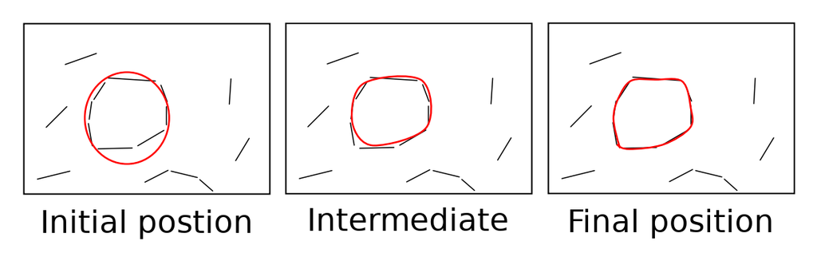

Illustration of the snakes model

The energy of the snakes is a combination of internal and external energy (“Snakes” 2011)

- **Internal Energy:** a metric that measures the curve’s smoothness or regularity.
- **External Energy:** a metric for measuring the data fidelity.

## Classification and representation

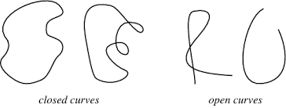

A curve has two different representations: **parametric** or **cartesian**.

In the parametric form, the points of the curve are expressed as a function of a real variable, conventionnally denoted $t$ representing *time*.

For instance, the parametric representation of circle in $\mathbb{R}^2$ is given by
$$\gamma: t\mapsto \begin{pmatrix}x_0+r\cos t\\y_0+r\sin t\end{pmatrix}$$
where the points of the curve are defined as $\Gamma = \mathrm{Im}(\gamma) = \left\{\gamma(t), t\in\mathbb{R}\right\}$.

The cartesian representation is an equation (or a set of equations) that describes the relations between the coordinates of the points of the curve. Such representation can be explicit $y=f(x)$ or implicit $f(x,y)=0$.

In the case of a circle, we can express it implicitly by
$$\Gamma = \left\{(x,y)\in\mathbb{R}^2\left\lvert\begin{matrix}(x-x_0)^2 + (y-y_0)^2 = r\end{matrix}\right.\right\}$$

or explicitly
$$\Gamma = \left\{(x,y)\in\mathbb{R}^2\left\lvert\begin{matrix}y=y_0+\sqrt{r-(x-x_0)^2}\\y=y_0-\sqrt{r-(x-x_0)^2}\end{matrix}\right.\right\}$$

Generally speaking, the parametric representation can be more expressive than cartesian equations. It is also worth noting that tracking a curve’s behaviour in a small neighborhood of a point on the curve is much simpler as the derivative of the parametric function $\gamma'(t)$ is easy to calculate and study.

- Parametric Edge-based Active Contours
- Implicit Edge-based Active Contours
- Rgion-based Active Contours

# Références

“Active Contour Model.” 2020. *Wikipedia*. https://en.wikipedia.org/w/index.php?title=Active_contour_model&oldid=940601399.

“Computer Vision.” 2020. *Wikipedia*. https://en.wikipedia.org/w/index.php?title=Computer_vision&oldid=939131357.

Peyré, Gabriel. 2011. “The Numerical Tours of Signal Processing - Advanced Computational Signal and Image Processing.” *IEEE Computing in Science and Engineering* 13 (4): 94–97. https://hal.archives-ouvertes.fr/hal-00519521.

“Snakes.” 2011. ICBE, University of Manchester. https://web.archive.org/web/20110716113957/http://www.isbe.man.ac.uk/courses/Computer_Vision/downloads/L11_Snakes.pdf.